# WildCard Results

2025-04-27

**Contingencies**

##### Low Value Options

- Fixed: 30
- Risky: 20 or 40

##### High Value Options

- Fixed: 70
- Risky: 60 or 80
- WC-Extreme: 5 or 95
- WC-NonExtreme: 45 or 55

##### Group 1 - Extreme First

- Block 1-3: WC-Extreme
- Block 4-6: WC-NonExtreme
- Block 7: No WC or feedback

##### Group 2 - Extreme Last

- Block 1-3: WC-NonExtreme
- Block 4-6: WC-Extreme
- Block 7: No WC or feedback

##### Group 3 - No Extreme

- Block 1-3: WC-NonExtreme
- Block 4-6: WC-NonExtreme
- Block 7: No WC or feedback

# **Participant Information**

**Pre-catch exclusion**

N = 390

| condition | sex | n | age_mean | age_sd | age_median | age_IQR | dur_minutes_mean | dur_minutes_median |
| --- | --- | --- | --- | --- | --- | --- | --- | --- |
| No Extreme | Female | 73 | 43.849 | 11.696 | 44 | 19.00 | 23.336 | 21.950 |
| No Extreme | Male | 52 | 41.346 | 12.228 | 38 | 20.25 | 24.293 | 21.708 |
| Extreme 1st | Female | 86 | 42.233 | 10.527 | 41 | 15.75 | 25.239 | 22.775 |
| Extreme 1st | Male | 63 | 42.778 | 9.980 | 41 | 15.00 | 25.689 | 22.867 |
| Extreme 2nd | Female | 72 | 44.750 | 11.610 | 46 | 15.75 | 24.641 | 21.483 |
| Extreme 2nd | Male | 44 | 38.955 | 10.764 | 38 | 15.25 | 34.079 | 22.600 |

**Post-catch exclusion**

N = 372

| condition | sex | n | age_mean | age_sd | age_median | age_IQR | dur_minutes_mean | dur_minutes_median |
| --- | --- | --- | --- | --- | --- | --- | --- | --- |
| No Extreme | Female | 68 | 43.706 | 11.722 | 43.5 | 19.25 | 23.119 | 21.817 |
| No Extreme | Male | 51 | 41.255 | 12.332 | 37.0 | 20.50 | 24.380 | 21.717 |
| Extreme 1st | Female | 82 | 42.366 | 10.121 | 41.0 | 15.00 | 25.264 | 22.408 |
| Extreme 1st | Male | 59 | 43.034 | 10.215 | 41.0 | 15.50 | 25.746 | 22.867 |
| Extreme 2nd | Female | 71 | 44.958 | 11.557 | 46.0 | 15.50 | 24.650 | 21.483 |
| Extreme 2nd | Male | 41 | 39.634 | 10.839 | 39.0 | 14.00 | 35.061 | 22.950 |

#### Condition totals:

| condition | n | age_mean | age_sd | age_median | age_IQR | dur_minutes_mean | dur_minutes_median |
| --- | --- | --- | --- | --- | --- | --- | --- |
| No Extreme | 119 | 42.655 | 11.997 | 41 | 20.5 | 23.660 | 21.717 |
| Extreme 1st | 141 | 42.645 | 10.129 | 41 | 15.0 | 25.466 | 22.767 |
| Extreme 2nd | 112 | 43.009 | 11.541 | 42 | 17.0 | 28.461 | 21.942 |

**Notes**

- Total number of catch trial exclusions = 18.
- Some participants reported a program crash during the memory phase. Their data is included in the numbers above. For reference:
  - 0 crashed in the first-outcome judgment.
  - 1 crashed in the frequency judgment.

# **Catch Trials**

**Plot - Block means and 95% CIs**

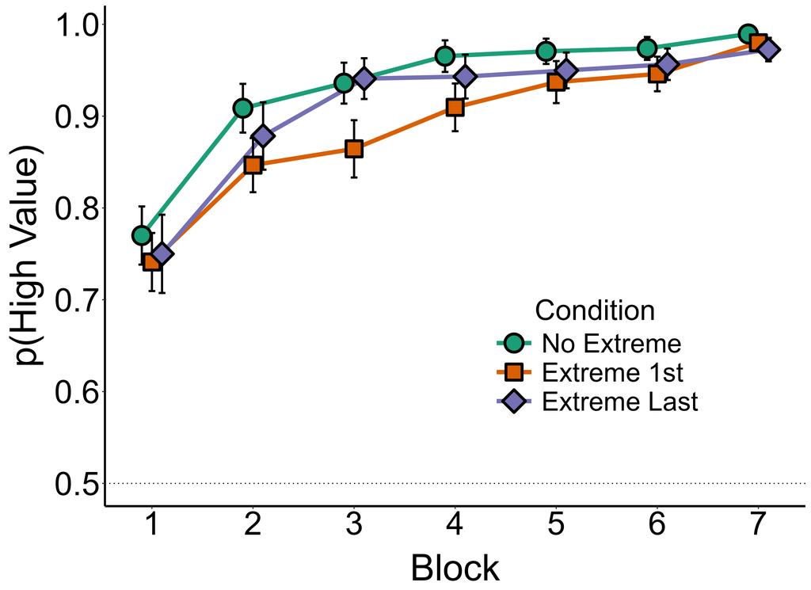

# **Risk-Preference**

**Plot - Block means with 95% CIs**

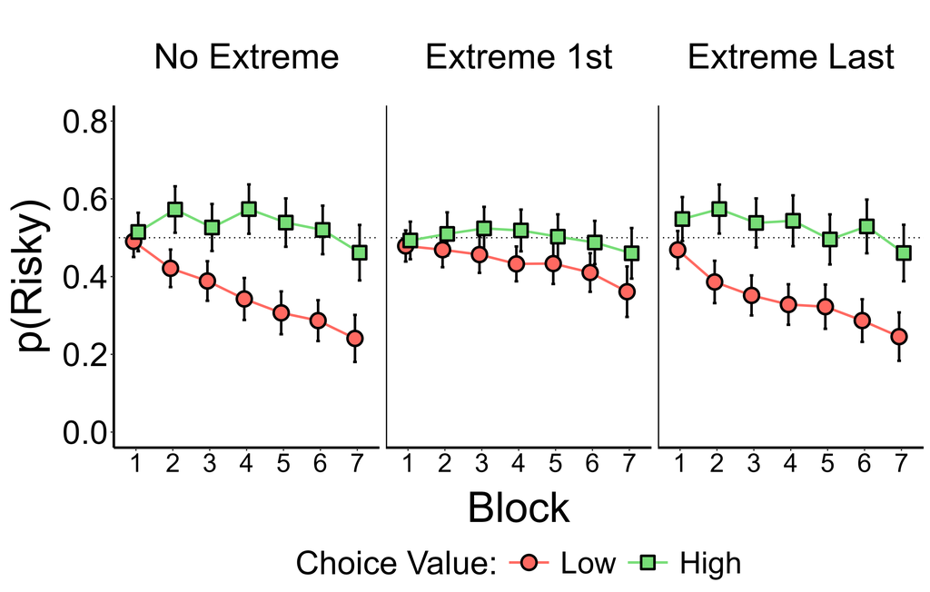

**Plot - Condition Differences with 95% CIs (Block 7)**

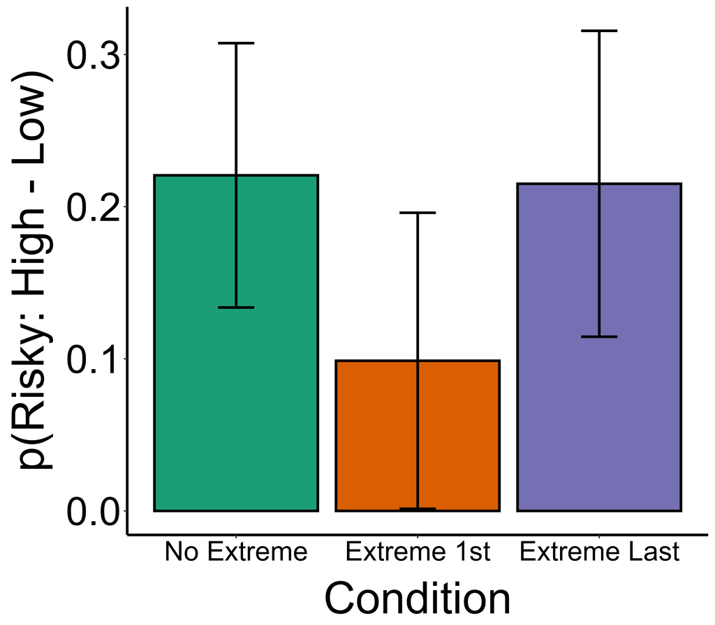

**Summary Statistics (Block 7)**

| condition | risky_choice | n | mean | sd | median | IQR |
| --- | --- | --- | --- | --- | --- | --- |
| No Extreme | Low | 119 | 0.241 | 0.333 | 0.000 | 0.458 |
| No Extreme | High | 119 | 0.461 | 0.393 | 0.500 | 0.917 |
| Extreme 1st | Low | 141 | 0.361 | 0.390 | 0.167 | 0.750 |
| Extreme 1st | High | 141 | 0.460 | 0.391 | 0.417 | 0.833 |
| Extreme Last | Low | 112 | 0.246 | 0.332 | 0.083 | 0.417 |
| Extreme Last | High | 112 | 0.461 | 0.388 | 0.417 | 0.833 |

**One-Way ANOVA on Difference (High - Low)**

#### Main Effect (L-Ratio)

|  | Model | df | AIC | BIC | logLik | Test | L.Ratio | p-value | BF_10 |
| --- | --- | --- | --- | --- | --- | --- | --- | --- | --- |
| null_mod | 1 | 2 | 599.879 | 607.716 | -297.939 |  | NA | NA | NA |
| diff_mod | 2 | 4 | 599.566 | 615.242 | -295.783 | 1 vs 2 | 4.313 | 0.116 | 0.023 |

**Effect of Condition:**

#### Main Effect (F-Ratio)

|  | numDF | F-value | p-value | pseudo_R2 |
| --- | --- | --- | --- | --- |
| (Intercept) | 1 | 38.329 | 0.000 | NA |
| condition | 2 | 2.151 | 0.118 | 0.014 |
| Residuals | 369 | NA | NA | NA |

**Effect of Condition:**

$F(2, 369) = 2.15, p = 0.118, R^2_N = 0.01$

#### Planned Contrasts

|  | Value | Std.Error | t-value | p-value | sig | DF | r_effect |
| --- | --- | --- | --- | --- | --- | --- | --- |
| (Intercept) | 0.099 | 0.045 | 2.178 | 0.015 | TRUE | 369 | 0.113 |
| conditionNE_v_E1 | 0.122 | 0.067 | 1.820 | 0.035 | TRUE | 369 | 0.094 |
| conditionE2_v_E1 | 0.116 | 0.068 | 1.708 | 0.044 | TRUE | 369 | 0.089 |

**No Extreme vs. Extreme First:**

$b = 0.12, t(369) = 1.82, p = 0.035, r = 0.094$

**Extreme Last vs. Extreme First:**

$b = 0.12, t(369) = 1.71, p = 0.044, r = 0.089$

- Note: p-values for these two planned contrasts reflect a one-sided hypothesis test as per the pre-registered hypotheses. i.e., (G1 < G2) & (G1 < G3). The Welch t-test below tests whether G2 = G3.

#### Welch Two-Sided T-test

**No Extreme vs. Extreme Last:**

$t(222.18) = 0.08$, $p = 0.934$, $d = 0.01$

**One-Way ANOVA on High Value Choices**

#### Main Effect

|  | numDF | F-value | p-value | pseudo_R2 |
| --- | --- | --- | --- | --- |
| (Intercept) | 1 | 516.849 | 0.000 | NA |
| condition | 2 | 0.001 | 0.999 | 0 |
| Residuals | 369 | NA | NA | NA |

**Effect of Condition:**

$F(2, 369) = 0, p = 0.999, R^2_N = 0$

#### Planned Contrasts

|  | Value | Std.Error | t-value | p-value | sig | DF | r_effect |
| --- | --- | --- | --- | --- | --- | --- | --- |
| (Intercept) | 0.460 | 0.033 | 13.973 | 0.000 | TRUE | 369 | 0.588 |
| conditionNE_v_E1 | 0.002 | 0.049 | 0.034 | 0.973 | FALSE | 369 | 0.002 |
| conditionE2_v_E1 | 0.001 | 0.049 | 0.015 | 0.988 | FALSE | 369 | 0.001 |

**No Extreme vs. Extreme First:**

$b = 0.002, t(369) = 0.03, p = 0.973, r = 0.002$

**Extreme Last vs. Extreme First:**

$b = 0.001, t(369) = 0.02, p = 0.988, r = 0.001$

- Note: These are two-sided tests.

#### Welch Two-Sided T-test

**No Extreme vs. Extreme Last:**

$t(228.46) = 0.02$, $p = 0.986$, $d = 0$

**One-Way ANOVA on Low Value Choices**

#### Main Effect

|  | numDF | F-value | p-value | pseudo_R2 |
| --- | --- | --- | --- | --- |
| (Intercept) | 1 | 243.860 | 0.000 | NA |
| condition | 2 | 4.824 | 0.009 | 0.047 |
| Residuals | 369 | NA | NA | NA |

**Effect of Condition:**

$F(2, 369) = 4.82, p = 0.009, R^2_N = 0.05$

#### Planned Contrasts

|  | Value | Std.Error | t-value | p-value | sig | DF | r_effect |
| --- | --- | --- | --- | --- | --- | --- | --- |
| (Intercept) | 0.361 | 0.030 | 12.061 | 0.000 | TRUE | 369 | 0.532 |
| conditionNE_v_E1 | -0.120 | 0.044 | -2.716 | 0.007 | TRUE | 369 | 0.140 |
| conditionE2_v_E1 | -0.116 | 0.045 | -2.568 | 0.011 | TRUE | 369 | 0.133 |

**No Extreme vs. Extreme First:**

$b = -0.12, t(369) = -2.72, p = 0.007, r = 0.14$

**Extreme Last vs. Extreme First:**

$b = -0.12, t(369) = -2.57, p = 0.011, r = 0.133$

- Note: These are two-sided tests.

#### Welch Two-Sided T-test

**No Extreme vs. Extreme Last:**

$t(228.26) = -0.11$, $p = 0.916$, $d = -0.01$

**Notes**

- NE = No Extreme; E1 = Extreme First; E2 = Extreme Last
- ANOVAs were run using generalized least-squares fit by maximum likelihood.
- $R^2_N$ is Nagelkerke’s (also known as Cragg and Uhler’s) pseudo $R^2$ (Nagelkerke, 1991). It isn’t interpreted in exactly the same way as a $R^2$ based on ordinary least-squares regression, but it is bounded by 0 and 1 and higher values indicate a better model fit.

# **First-Outcome Judgement**

**Plot - Proportions**

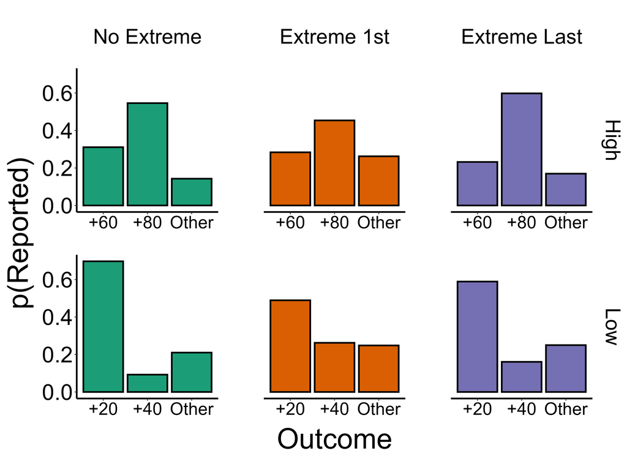

Note:

- Proportions are taken within condition and context (High/Low). E.g., All the green bars in the top left sum to 1, all the orange bars in the top middle sum to 1, and so on.
- The colour palette is colourblind friendly.

## Pre-Registered Analysis

**McNemar Test Results**

| Condition | Statistic | df | p.value | OR | Cohen_g | lower_g_ci | upper_g_ci |
| --- | --- | --- | --- | --- | --- | --- | --- |
| Extreme 1st | 10.316 | 1 | 0.001 | 2.17 | 0.184 | 0.084 | 0.287 |
| Extreme Last | 24.242 | 1 | 0.000 | 4.08 | 0.303 | 0.206 | 0.398 |
| No Extreme | 32.143 | 1 | 0.000 | 6.00 | 0.357 | 0.268 | 0.445 |

Effect Size Interpretation

|  | Small | Medium | Large |
| --- | --- | --- | --- |
| Cohen’s g | 0.05 : 0.15 | 0.15 : 0.25 | ≥ 0.25 |
| Odds Ratio > 1 | 1.22 : 1.86 | 1.86 : 3.00 | ≥ 3.00 |
| Odds Ratio < 1 | 0.820 : 0.538 | 0.538 : 0.333 | ≤ 0.333 |

Note:

- Table shows Cohen’s $g$ not Hedge’s $g$ (which is a variant of Cohen’s $d$).

**McNemar Test Conclusions**

#### Extreme First Condition:

|  | No | Yes |
| --- | --- | --- |
| High | 31 | 52 |
| Low | 24 | 59 |

$\chi^2(1) = 10.32, p = 0.001$

- There is a significant change in judgement evaluation between the high and low risky doors.
- The odds of stating the extreme value given they are seeing the high-risk door is 2.17 times that of seeing the low-risk door and not stating the extreme value.

#### Extreme Last Condition:

|  | No | Yes |
| --- | --- | --- |
| High | 20 | 53 |
| Low | 13 | 60 |

$\chi^2(1) = 24.24, p = 0$

- There is a significant change in judgement evaluation between the high and low risky doors.
- The odds of stating the extreme value given they are seeing the high-risk door is 4.08 times that of seeing the low-risk door and not stating the extreme value.

#### No Extreme Condition:

|  | No | Yes |
| --- | --- | --- |
| High | 27 | 54 |
| Low | 9 | 72 |

$\chi^2(1) = 32.14, p = 0$

- There is a significant change in judgement evaluation between the high and low risky doors.
- The odds of stating the extreme value given they are seeing the high-risk door is 6 times that of seeing the low-risk door and not stating the extreme value.

## Alternative Analysis

**2x3 Chi-Squared Tests**

#### High Value Results

High Value Contingency Table

|  | No | Yes |
| --- | --- | --- |
| No Extreme | 27 | 54 |
| Extreme 1st | 31 | 52 |
| Extreme Last | 20 | 53 |

$\chi^2(2) = 1.75, p = 0.416, \varphi_c = 0.09$

- Cannot rule out that recalling the extreme value is independent of condition.

Standardized Residuals

|  | No | Yes |
| --- | --- | --- |
| No Extreme | 0.10 | -0.10 |
| Extreme 1st | 1.07 | -1.07 |
| Extreme Last | -1.21 | 1.21 |

p-values

|  | No | Yes |
| --- | --- | --- |
| No Extreme | 0.921 | 0.921 |
| Extreme 1st | 0.286 | 0.286 |
| Extreme Last | 0.228 | 0.228 |

- None of the three conditions differ significantly from the expected value.

#### Low Value Results

Low Value Contingency Table

|  | No | Yes |
| --- | --- | --- |
| No Extreme | 9 | 72 |
| Extreme 1st | 24 | 59 |
| Extreme Last | 13 | 60 |

$\chi^2(2) = 8.48, p = 0.014, \varphi_c = 0.19$

- Recalling the extreme value is dependent on condition; however, the association/effect is a weak/small one.

Standardized Residuals

|  | No | Yes |
| --- | --- | --- |
| No Extreme | -2.33 | 2.33 |
| Extreme 1st | 2.72 | -2.72 |
| Extreme Last | -0.42 | 0.42 |

p-values

|  | No | Yes |
| --- | --- | --- |
| No Extreme | 0.020 | 0.020 |
| Extreme 1st | 0.007 | 0.007 |
| Extreme Last | 0.678 | 0.678 |

The *No Extreme* and *Extreme 1st* conditions both differ significantly from the expected value. The *No Extreme* condition tends to recall the extreme value, whereas *Extreme 1st* does not.

- No Extreme: $z = 2.33, p = 0.02$
- Extreme 1st: $z = -2.72, p = 0.007$

#### Post-Hoc Pairwise Fisher-Exact Tests

| value | comparison | odds_ratio | p_value | CI_low | CI_upper | p_value_adj |
| --- | --- | --- | --- | --- | --- | --- |
| High | No Extreme : Extreme 1st | 0.8396 | 0.6266 | 0.4197 | 1.6728 | 0.9700 |
| High | No Extreme : Extreme Last | 1.3226 | 0.4850 | 0.6284 | 2.8166 | 0.9700 |
| High | Extreme 1st : Extreme Last | 1.5752 | 0.2316 | 0.7601 | 3.3165 | 0.9264 |
| Low | No Extreme : Extreme 1st | 0.3095 | 0.0060 | 0.1171 | 0.7541 | 0.0359 |
| Low | No Extreme : Extreme Last | 0.5790 | 0.2573 | 0.2032 | 1.5807 | 0.9264 |
| Low | Extreme 1st : Extreme Last | 1.8700 | 0.1317 | 0.8239 | 4.4044 | 0.6583 |

- Recalling the extreme value was found to be dependent on condition ($p = 0.036$) only when low value options in the No Extreme and Extreme First conditions are considered (Row 4 in the table). Everything else fails to reach significance.

Note:

- In the contingency tables, ‘Yes’ indicates the extreme value was recalled, ‘No’ indicates that it was not.
- Only recalled outcomes that matched the programmed values were included. i.e., if they saw the *High Value Risky Door*, 80 was logged as “Yes” and 60 was logged as “No.” If they saw the *Low Value Risky Door*, 20 was logged as “Yes”, 40 was logged as “No”. Participants who responded with any “other” values were removed from the analysis. Only Risky doors were evaluated.
- In total, removing “other” responses resulted 135 participants being excluded from these analyses leaving a final N = 237.
- $\varphi_c$ is Cramér’s V, a measure of association for two nominal variables (i.e., an effect size of sorts). It can take a value between 0 and 1, with 0 indicating no association (i.e., full independence).
- Post-hoc analysis on each $\chi^2$ test was conducted by evaluating the standardized residuals from the chi-square analysis because it seemed the most intuitive approach. However, pairwise Pearson Chi-squared or Fisher Exact tests across the three conditions were also run. The `p_value_adj` column shows corrected p-values using the Holm-Bonferroni method.

# **Frequency Judgement**

**Plot - Means and 95% CIs**

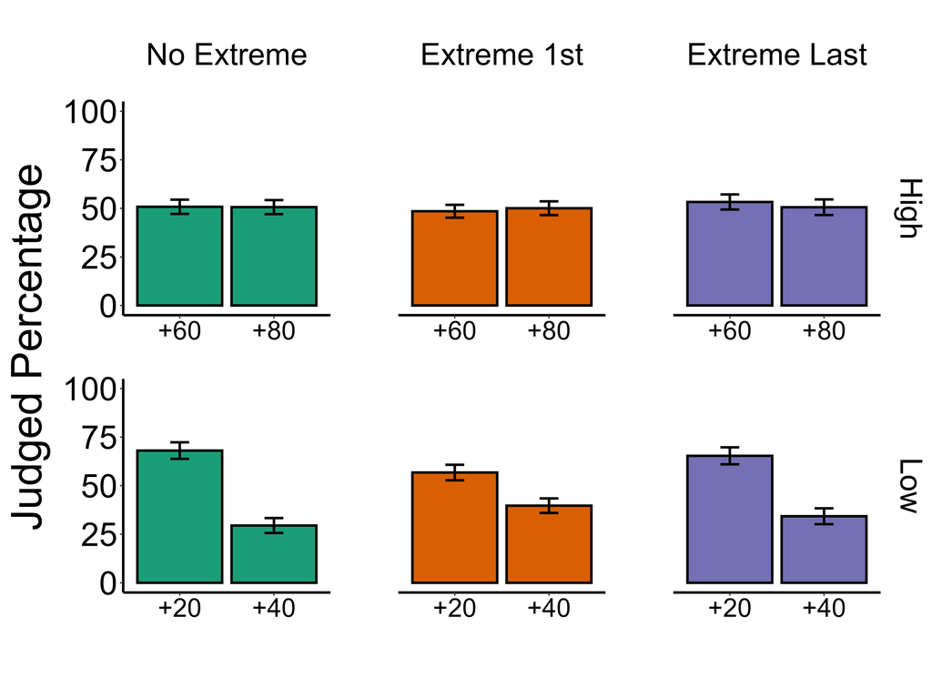

**Table - Plotting Values**

| context | outcome | condition | n | mean | sd | median | IQR |
| --- | --- | --- | --- | --- | --- | --- | --- |
| High | +60 | No Extreme | 118 | 50.805 | 20.102 | 50 | 20.00 |
| High | +60 | Extreme 1st | 141 | 48.496 | 19.928 | 50 | 20.00 |
| High | +60 | Extreme Last | 112 | 53.268 | 20.721 | 50 | 26.25 |
| High | +80 | No Extreme | 118 | 50.636 | 19.797 | 50 | 20.00 |
| High | +80 | Extreme 1st | 141 | 50.050 | 21.320 | 50 | 20.00 |
| High | +80 | Extreme Last | 112 | 50.571 | 21.502 | 50 | 20.00 |
| Low | +20 | No Extreme | 118 | 68.051 | 23.352 | 70 | 40.00 |
| Low | +20 | Extreme 1st | 141 | 56.759 | 23.962 | 55 | 35.00 |
| Low | +20 | Extreme Last | 112 | 65.348 | 23.394 | 70 | 30.00 |
| Low | +40 | No Extreme | 118 | 29.483 | 21.033 | 25 | 40.00 |
| Low | +40 | Extreme 1st | 141 | 39.695 | 22.433 | 40 | 30.00 |
| Low | +40 | Extreme Last | 112 | 34.250 | 21.831 | 30 | 30.00 |

**2x3 ANOVA using linear mixed-effects models fit by maximum likelihood**

#### Main Effects

|  | Model | df | AIC | BIC | logLik | Test | L.Ratio | p.value | BF_10 |
| --- | --- | --- | --- | --- | --- | --- | --- | --- | --- |
| base | 1 | 4 | 6788.378 | 6806.816 | -3390.189 |  | NA | NA | NA |
| cond_mod | 2 | 6 | 6783.017 | 6810.673 | -3385.508 | 1 vs 2 | 9.362 | 0.009 | 1.45000e-01 |
| HL_mod | 3 | 7 | 6727.837 | 6760.102 | -3356.918 | 2 vs 3 | 57.180 | 0.000 | 9.57785e+10 |
| int_mod | 4 | 9 | 6723.163 | 6764.647 | -3352.581 | 3 vs 4 | 8.674 | 0.013 | 1.03000e-01 |

**Main Effect of Condition:**

$\chi^2(2) = 9.36$, $p = 0.009$, $BF_{10} = 0.145$

**Main Effect of Value (High vs. Low):**

$\chi^2(1) = 57.18$, $p < 0.001$, $BF_{10} > 150$

**Interaction:**

$\chi^2(2) = 8.67$, $p = 0.013$, $BF_{10} = 0.103$

#### Planned Contrasts

|  | Value | Std.Error | DF | t-value | p-value | r_effect |
| --- | --- | --- | --- | --- | --- | --- |
| (Intercept) | 53.404 | 1.365 | 368 | 39.130 | 0.000 | 0.898 |
| conditionNE_v_E1 | 5.939 | 2.022 | 368 | 2.937 | 0.002 | 0.151 |
| conditionE2_v_E1 | 4.556 | 2.051 | 368 | 2.221 | 0.013 | 0.115 |
| FJ_context1 | -3.355 | 1.289 | 368 | -2.602 | 0.010 | 0.134 |
| conditionNE_v_E1:FJ_context1 | -5.353 | 1.910 | 368 | -2.803 | 0.005 | 0.145 |
| conditionE2_v_E1:FJ_context1 | -4.034 | 1.937 | 368 | -2.082 | 0.038 | 0.108 |

**No Extreme vs. Extreme First:**

$b = 5.939$, $t(368) = 2.94$, $p = 0.002$, $r = 0.151$

**Extreme Last vs. Extreme First:**

$b = 4.556$, $t(368) = 2.22$, $p = 0.013$, $r = 0.115$

**No Extreme vs. Extreme First | Value (High vs. Low):**

$b = -5.353$, $t(368) = -2.8$, $p = 0.005$, $r = 0.145$

**Extreme Last vs. Extreme First | Value (High vs. Low):**

$b = -4.034$, $t(368) = -2.08$, $p = 0.038$, $r = 0.108$

- IMPORTANT: p-values were adjusted for a one-sided hypothesis only for the first two planned contrasts. Since the interaction had no predicted direction, they were left as two-sided.

#### Welch Two-Sided T-test

**No Extreme vs. Extreme Last:**

$t(456.04) = 0.63$, $p = 0.528$, $d = 0.06$

**Notes**

- ANOVA was conducted only on judgements for the risky extreme values (+20 and +80).
- NE = No Extreme; E1 = Extreme First; E2 = Extreme Last
- Bayes Factors are reported as Inverse Bayes Factors, this means larger values indicate greater support for the effect. Anything less than 1 should be considered as contributing no evidence.

# **R Citations**

R version 4.4.2 (2024-10-31 ucrt)

- Hmisc (5.1.3) (Harrell Jr, 2024)
- rcompanion (2.4.36) (Mangiafico, 2024)
- RColorBrewer (1.1.3) (Neuwirth, 2022)
- patchwork (1.2.0) (Pedersen, 2024)
- nlme (3.1.166) (Pinheiro et al., 2023)
- effsize (0.8.1) (Torchiano, 2020)
- ggh4x (3.1.166) (van den Brand, 2024)
- tidyverse (2.0.0) (Wickham et al., 2019)

# **References**

Harrell Jr, F. E. (2024). *Hmisc: Harrell miscellaneous*. https://CRAN.R-project.org/package=Hmisc

Mangiafico, S. S. (2024). *rcompanion: Functions to support extension education program evaluation*. Rutgers Cooperative Extension. https://CRAN.R-project.org/package=rcompanion/

Nagelkerke, N. J. D. (1991). A note on a general definition of the coefficient of determination. *Biometrika*, *78*(3), 691–692. https://doi.org/10.2307/2337038

Neuwirth, E. (2022). *RColorBrewer: ColorBrewer palettes*. https://CRAN.R-project.org/package=RColorBrewer

Pedersen, T. L. (2024). *Patchwork: The composer of plots*. https://CRAN.R-project.org/package=patchwork

Pinheiro, J., Bates, D., & R Core Team. (2023). *Nlme: Linear and nonlinear mixed effects models*. https://CRAN.R-project.org/package=nlme

R Core Team. (2024). *R: A language and environment for statistical computing*. R Foundation for Statistical Computing. https://www.R-project.org/

Torchiano, M. (2020). *Effsize: Efficient effect size computation*. https://doi.org/10.5281/zenodo.1480624

van den Brand, T. (2024). *ggh4x: Hacks for ’ggplot2’*. https://CRAN.R-project.org/package=ggh4x

Wickham, H., Averick, M., Bryan, J., Chang, W., McGowan, L. D., François, R., Grolemund, G., Hayes, A., Henry, L., Hester, J., Kuhn, M., Pedersen, T. L., Miller, E., Bache, S. M., Müller, K., Ooms, J., Robinson, D., Seidel, D. P., Spinu, V., … Yutani, H. (2019). Welcome to the tidyverse. *Journal of Open Source Software*, *4*(43), 1686. https://doi.org/10.21105/joss.01686